# seeprogress

GuohuanZhang

2022-10-24

## R Markdown

This is the 5th R Markdown document of GuohuanZhang.

### This R Markdown document aims to show how to see progress of your program

### Find more at https://github.com/Thuoyuing/Thuoyuing.github.io

### 最近在计算一些运算量比较大的东西，非常耗时。

### 对多个变量计算同一指标，通常需要用到循环或者map、lapply。

### 但是当计算一个变量需要的时间比较长时，R的Console会长时间的没有反馈，不知道程序具体计算到哪一步。

### 这时候在程序中加上一些消息提醒会比较方便、友好。

```r
if(!require(pacman)){
  install.packages("pacman")
}
```

```r
pacman::p_load(tidyverse, # 整洁代码
               tictoc,    # 计算运算时间
               lubridate, # 获取当前时间
               progress,  # 进度条
               furrr)     # map循环
rm(list = ls())
```

### 先随便生成一些用来批量计算的变量

```r
tibble(V1 = rnorm(50000,50,5),
       V2 = rnorm(50000,60,10),
       V3 = rnorm(50000,70,15),
       V4 = rnorm(50000,80,20),
       V5 = rnorm(50000,90,25),
       V6 = rnorm(50000,100,30),
       V7 = rnorm(50000,110,40)) -> Data
```

### 再定义一个计算量稍微大点的函数。

### 这里是根据提供的变量名，提取出需要的变量并按一个公式计算

```r
HCal <- function(Vname){
  Data %>% select(all_of(Vname)) %>% as_vector() -> dt.vector
  future_map(dt.vector,
             ~sum(abs(.-dt.vector))) %>%
    as_vector() %>%
    sum()
}
```

### 正常计算的话，直接对Data的变量名map一下HCal这个函数就行了

```r
Data %>% names() -> Vnames # 提取出Data的变量名
map(Vnames,               # 对每个变量名都用HCal进行同样的计算
    HCal)
```

```
## [[1]]
## [1] 14060768481
##
## [[2]]
## [1] 28160783398
##
## [[3]]
## [1] 42471335238
##
## [[4]]
## [1] 56419506906
##
## [[5]]
## [1] 70467423163
##
## [[6]]
## [1] 84600286245
##
## [[7]]
## [1] 112396919609
```

### 这是比较耗时间的，而且在算完前，Console不会给你任何提示。只有在算完后给出结果。

### 现在我们在HCal中内嵌入提示程序进程的一些代码

**1.tictoc提示所用时间，用在函数的开头和结尾**

**2.message提示循环进度，用在当前循环的开头，也就是在函数的开头就行**

**3.lubridate::now()获取当前时间，和message合在一起**

```r
HCal1 <- function(Vname){
  tictoc::tic()          # 开始计时
  lubridate::now() %>%
    stringr::str_replace_all(":",".") %>%
    stringr::str_replace_all("-",".") -> NowTime  # 获取当前时间
  # message()输出提示语句
  # 其中使用stringr::str_c把需要提示的语句和当前时间合并为一个字符串
  # which(Vname==Vnames),"/",length(Vnames) 用分数提示当前的进度
  message(stringr::str_c("Now calculating Data for ",Vname,"...Total process--",
                         which(Vname==Vnames),"/",length(Vnames),"...",NowTime))
  Data %>% select(all_of(Vname)) %>% as_vector() -> dt.vector
  future_map(dt.vector,
             ~sum(abs(.-dt.vector))) %>%
    as_vector() %>%
    sum()
  tictoc::toc()          # 结束计时
}
```

### 现在再重新计算一下

### 就可以看到给出了计算的进度、当前时间以及上一循环所用的时间

### 完成后这些信息也留在Console里，晚上睡前开始计算，早上起床后也能把握程序的详细进度。

```r
map(Vnames,
    HCal1)
```

```
## Now calculating Data for V1...Total process--1/7...2022.10.24 12.44.00
```

```
## 17.21 sec elapsed
```

```
## Now calculating Data for V2...Total process--2/7...2022.10.24 12.44.17
```

```
## 18.25 sec elapsed
```

```
## Now calculating Data for V3...Total process--3/7...2022.10.24 12.44.36
```

```
## 21.85 sec elapsed
```

```
## Now calculating Data for V4...Total process--4/7...2022.10.24 12.44.58
```

```
## 18.84 sec elapsed
```

```
## Now calculating Data for V5...Total process--5/7...2022.10.24 12.45.16
```

```
## 17.36 sec elapsed
```

```
## Now calculating Data for V6...Total process--6/7...2022.10.24 12.45.34
```

```
## 17.2 sec elapsed
```

```
## Now calculating Data for V7...Total process--7/7...2022.10.24 12.45.51
```

```
## 16.38 sec elapsed
```

[output not shown]

[output cut: 34 more lines]

[output not shown]

### 另外，还有一种提示循环进度的方法

### 用这种方法会在Console中实时显示一个在填充的进度条

### 缺点是只有当第一个循环完成时才会出现，并且当计算完毕后也会消失。

首先设置循环的总次数

```r
N = length(Vnames)
```

生成一个进度条

这个进度条属于R6 class，按照语法实例化一个总循环次数为N的进度条

```r
Bar <- progress_bar$new(total = N)
```

定义一个用来存放计算结果的空向量

```r
res <- vector()
```

用for循环计算各个变量

```r
for (ii in 1:N) {
  Bar$tick()
  Vname = Vnames[ii]
  HCal(Vname) -> res[ii]
}
res
```

```
## [1]  14060768481  28160783398  42471335238  56419506906  70467423163
## [6]  84600286245 112396919609
```

R Markdown只会显示程序运行完后的结果，所以这里没有进度条。

在运行过程中是可以看到进度条的

# 就像下面这样

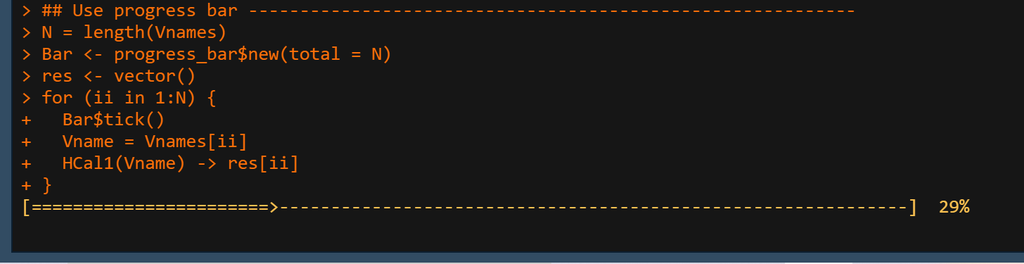